# `WEB SCRAPING AND EXPLORATORY DATA ANALYSIS OF FACTORS AFFECTING USED PRODUCT PRICES IN THE RESALE MARKET`

# Web Scraping Overview

Data Collection for Resale Market Analysis

1. Introduction to Web Scraping

Web scraping is the process of automatically extracting data from websites using programming tools instead of manual collection. In data science projects, web scraping is commonly used when structured datasets are not readily available and real-world data must be collected directly from online platforms.

In this project, web scraping was used to collect used product resale listings from an e-commerce platform in order to analyze pricing patterns, market inefficiencies, and buyer–seller behavior.

2. Need for Web Scraping in This Project

The resale market lacks publicly available, clean datasets that include:

- Product prices
- Condition
- Brand information
- Shipping cost
- Warranty status
- Sales performance

To overcome this limitation, web scraping was adopted to:

- Collect real-time resale listings
- Capture pricing variability
- Reflect actual market behavior
- Build a dataset suitable for Exploratory Data Analysis (EDA)
3. Data Source

The data was scraped from an online resale marketplace (eBay), which provides:

A wide range of used products

Transparent pricing and shipping details

Product condition and seller information

Sales and popularity indicators

This platform was chosen due to its large resale ecosystem and data richness.

4. Tools & Libraries Used

The following Python libraries were used for web scraping:

- Requests – To send HTTP requests and fetch web pages
- BeautifulSoup (bs4) – To parse HTML content and extract required elements
- Pandas – To store and structure scraped data
- Time – To control request frequency and avoid overloading the website
5. Web Scraping Methodology

The scraping process followed a structured and ethical approach:

Step 1: Sending HTTP Requests

An HTTP request was sent to the target webpage containing resale listings to retrieve the HTML content.

Step 2: Parsing HTML Content

The retrieved HTML was parsed using BeautifulSoup to locate specific HTML tags corresponding to:

- Product name
- Brand
- Price range
- Shipping cost
- Condition
- Warranty information
- Sales count (if available)

Step 3: Extracting Relevant Fields

Each listing was iterated through, and relevant attributes were extracted using:

- HTML class names
- Tag hierarchies
- CSS selectors

Step 4: Data Storage

The extracted data was stored in:

- Python lists
- Converted into a Pandas DataFrame
- Exported as a CSV file for further analysis

Step 5: Data Cleaning

- Post-scraping, the data was cleaned by:
- Removing missing values
- Converting price strings to numeric format
- Standardizing condition and brand names
6. Sample Web Scraping Code (Conceptual) import requests from bs4 import BeautifulSoup import pandas as pd

url = "https://www.ebay.com/sch/i.html?_nkw=used+smartphone" response = requests.get(url)

soup = BeautifulSoup(response.text, "html.parser")

products = soup.find_all("div", class_="s-item")

data = []

```
if name and price:
    data.append({
        "Product_Name": name.text,
        "Price": price.text,
        "Shipping": shipping.text if shipping else "Not Available"
    })
```

df = pd.DataFrame(data)

(Note: This code demonstrates the scraping logic used in the project notebook.)

7. Ethical Considerations

Only publicly available data was collected

No personal user data was scraped

Request frequency was controlled to prevent server overload

The data was used strictly for academic and analytical purposes

8. Outcome of Web Scraping

The web scraping process resulted in:

- A structured dataset of resale listings
- Real-world pricing information
- Rich attributes for EDA and hypothesis testing
- This dataset served as the foundation for analyzing resale price behavior and market inefficiencies.
9. Conclusion

`Web scraping enabled the collection of authentic resale market data that would otherwise be unavailable. By leveraging Python-based scraping techniques, this project successfully transformed unstructured web data into a structured dataset suitable for exploratory analysis, visualization, and statistical testing.`

```python
import pandas as pd
```

```python
df = pd.read_csv(r"C:\Users\hi\Downloads\raw_data (1).csv")
```

```python
df
```

|  | Name | Type | Product_Type | Price | Shipment | NO_of_sold |
| --- | --- | --- | --- | --- | --- | --- |
| 0 | Apple iPhone 14 Pro, Fully Unlocked - Refurbi... | NaN | NaN | $359.99 to $424.99 | Free international shipping | NaN |
| 1 | Google Pixel 7 \| 7a \| 7 Pro 128GB \| 256GB - Un... | NaN | NaN | $170.95 to $261.20 | Free international shipping | 181 sold |
| 2 | Apple iPhone 11 Fully Unlocked SmartPhone 64GB... | NaN | NaN | $173.00 to $220.00 | Free international shipping | 38 sold |
| 3 | Samsung Galaxy S10 S10e S10+ Plus 128GB 512GB ... | NaN | NaN | $123.45 to $227.95 | Free international shipping | NaN |
| 4 | Apple iPhone 16 Pro 512GB Unlocked AT&T T-Mobi... | FREE FEDEX 2 DAY - 60 DAY RETURNS - 1 YEAR WAR... | NaN | $774.95 | Free international shipping | 69 sold |
| ... | ... | ... | ... | ... | ... | ... |
| 2035 | Apple iPhone 12 A2172 (Fully Unlocked) 64GB Bl... | NaN | NaN | $172.99 | Free international shipping | 810 sold |
| 2036 | Apple iPhone 16 Plus A3082 Unlocked 128GB Pink C | Free Shipping, Free 30 Day Returns | NaN | $487.19 | Free international shipping | Only 1 left! |
| 2037 | NEW Samsung Galaxy Note 10+ Plus 256GB N975U A... | NaN | NaN | $218.89 to $223.89 | Free international shipping | NaN |
| 2038 | NEW Motorola RAZR+ Plus 2025 5G XT2557 256GB A... | 🏆 Trusted Seller \| 💰 50% OFF \| 🚚FAST 2-Day Shi... | NaN | $479.00 to $498.00 | Free international shipping | 20 sold |
| 2039 | Apple iPhone 13 128GB 256GB 5G Unlocked Verizo... | NaN | NaN | $216.00 to $301.00 | Free international shipping | NaN |

2040 rows × 6 columns

```python
import warnings
warnings.filterwarnings('ignore')
```

```python
import pandas as pd
import numpy as np

df = pd.read_csv(r"C:\Users\hi\Downloads\raw_data (1).csv")

# Drop fully empty column
df.drop(columns=['Product_Type'], inplace=True)

# Remove duplicates
df.drop_duplicates(inplace=True)

# Clean Price column (remove currency symbols)
df['Price'] = df['Price'].str.replace(r'[^0-9]', '', regex=True)
df['Price'] = pd.to_numeric(df['Price'], errors='coerce')

# Clean NO_of_sold
df['NO_of_sold'] = df['NO_of_sold'].str.replace(r'[^0-9]', '', regex=True)
df['NO_of_sold'] = pd.to_numeric(df['NO_of_sold'], errors='coerce')

# Handle missing values
df['Price'].fillna(df['Price'].median(), inplace=True)
df['NO_of_sold'].fillna(df['NO_of_sold'].median(), inplace=True)
df['Type'].fillna(df['Type'].mode()[0], inplace=True)

df.info()
```

```
<class 'pandas.core.frame.DataFrame'>
Index: 60 entries, 0 to 59
Data columns (total 5 columns):
 #   Column      Non-Null Count  Dtype
---  ------      --------------  -----
 0   Name        60 non-null     object
 1   Type        60 non-null     object
 2   Price       60 non-null     int64
 3   Shipment    60 non-null     object
 4   NO_of_sold  60 non-null     float64
dtypes: float64(1), int64(1), object(3)
memory usage: 2.8+ KB
```

```python
df.columns
```

```
Index(['Name', 'Type', 'Price', 'Shipment', 'NO_of_sold'], dtype='object')
```

```python
df.shape
```

```
(60, 5)
```

```python
df
```

|  | Name | Type | Price | Shipment | NO_of_sold |
| --- | --- | --- | --- | --- | --- |
| 0 | Apple iPhone 14 Pro, Fully Unlocked - Refurbi... | Ships Same Day - Charger Included - Free Returns | 3599942499 | Free international shipping | 57.0 |
| 1 | Google Pixel 7 \| 7a \| 7 Pro 128GB \| 256GB - Un... | Ships Same Day - Charger Included - Free Returns | 1709526120 | Free international shipping | 181.0 |
| 2 | Apple iPhone 11 Fully Unlocked SmartPhone 64GB... | Ships Same Day - Charger Included - Free Returns | 1730022000 | Free international shipping | 38.0 |
| 3 | Samsung Galaxy S10 S10e S10+ Plus 128GB 512GB ... | Ships Same Day - Charger Included - Free Returns | 1234522795 | Free international shipping | 57.0 |
| 4 | Apple iPhone 16 Pro 512GB Unlocked AT&T T-Mobi... | FREE FEDEX 2 DAY - 60 DAY RETURNS - 1 YEAR WAR... | 77495 | Free international shipping | 69.0 |
| 5 | Samsung Galaxy A07 64GB & 128GB 4G Dual-Sim U... | Ships Same Day - Charger Included - Free Returns | 896710470 | $16.65 shipping | 51.0 |
| 6 | NEW UNLOCKED SAMSUNG GALAXY S21 ULTRA 5G SM-G9... | 🔥WINTER SALE🔥FREE PRIORITY SHIP🔥BEST DEAL ON E... | 2598837988 | Free international shipping | 2198.0 |
| 7 | Google Pixel 3 / 3 XL / 3a / 3a XL - 64GB/128G... | Ships Same Day - Charger Included - Free Returns | 782612932 | Free international shipping | 117.0 |
| 8 | NOKIA 9210 RAE-3N COMMUNICATOR MOBILE PHONE UN... | Ships Same Day - Charger Included - Free Returns | 17468 | $46.57 shipping | 59.0 |
| 9 | Samsung Galaxy S23 S911U Straight Talk Unlocke... | Ships Same Day - Charger Included - Free Returns | 1994926599 | Free international shipping | 57.0 |
| 10 | AT&T Motorola Razr+ Plus 5G 256GB Black XT2321... | Ships Same Day - Charger Included - Free Returns | 15895 | Free international shipping | 1.0 |
| 11 | Poco X3 Pro 256GB+8GB Phantom Black Factory Un... | Ships Same Day - Charger Included - Free Returns | 11500 | Free international shipping | 102.0 |
| 12 | Apple iPhone 14 Pro 128GB Unlocked 6.1" - (Bla... | Ships Same Day - Charger Included - Free Returns | 37072 | Free international shipping | 331.0 |
| 13 | Apple iPhone 6S Plus 16GB 32GB 64GB 128GB Unlo... | Free 2 Day Shipping! | 54999499 | Free international shipping | 84.0 |
| 14 | Apple iPhone 12, 64/128/256GB - Unlocked - Re... | Ships Same Day - Charger Included - Free Returns | 2099923999 | Free international shipping | 57.0 |
| 15 | Motorola Moto Razr XT2323 128GB Green (Unlocke... | Ships Same Day - Charger Included - Free Returns | 25899 | Free international shipping | 57.0 |
| 16 | NEW UNLOCKED SAMSUNG GALAXY S20 ULTRA 5G SM-G9... | 🔥WINTER SALE🔥FREE PRIORITY SHIP🔥BEST DEAL ON E... | 22888 | Free international shipping | 723.0 |
| 17 | Apple iPhone 14 Pro - 128GB 256GB 512GB 1TB - ... | Ships Same Day - Charger Included - Free Returns | 3750044500 | Free international shipping | 7.0 |
| 18 | Samsung Galaxy S25 Edge SM-S937U T-Mobile Only... | Ships Same Day - Charger Included - Free Returns | 54999 | Free international shipping | 57.0 |
| 19 | Google Pixel 9 - 9 Pro-9 Pro XL - 128/256GB - ... | Ships Same Day - Charger Included - Free Returns | 3799948999 | Free international shipping | 57.0 |
| 20 | Apple iPhone 14 Plus 128GB Midnight Unlocked E... | Ships Same Day - Charger Included - Free Returns | 30900 | Free international shipping | 57.0 |
| 21 | ⚡45W Type USB C Super Fast Wall Charger 6ft Ca... | Ships Same Day - Charger Included - Free Returns | 199 | Free international shipping | 1.0 |
| 22 | UMIDIGI A9 64GB Unlocked Android Smartphone 4G... | Ships Same Day - Charger Included - Free Returns | 6999 | Free international shipping | 2.0 |
| 23 | Xiaomi Redmi 13C 4G LTE Clover Green - 8GB RAM... | Ships Same Day - Charger Included - Free Returns | 9998 | Free international shipping | 94.0 |
| 24 | Apple iPhone 14 Pro Fully Unlocked With eSIM 1... | Free Shipping** 1 Year Warranty ** Free Returns | 37000 | Free international shipping | 57.0 |
| 25 | Samsung Galaxy S22 Ultra S908U1 128GB 256GB 51... | Ships Same Day - Charger Included - Free Returns | 2519930495 | Free international shipping | 16.0 |
| 26 | Alcatel 1 (5033E) – 5.0" – 1GB RAM / 16GB – An... | Ships Same Day - Charger Included - Free Returns | 2550 | Free international shipping | 24.0 |
| 27 | Oppo Find X9 Pro 5G 512GB 16GB SILK WHITE GSM ... | Ships Same Day - Charger Included - Free Returns | 94900 | Free international shipping | 57.0 |
| 28 | Apple iPhone 6 16GB 64GB Unlocked Excellent Co... | Ships Same Day - Charger Included - Free Returns | 41008200 | Free international shipping | 51.0 |
| 29 | Samsung Galaxy S23 5G S911U Verizon Straight T... | Ships Same Day - Charger Included - Free Returns | 2099928999 | Free international shipping | 57.0 |
| 30 | *NEW* Samsung Galaxy S25 FE 5G SM-S731U1 UNLOC... | Ships Same Day - Charger Included - Free Returns | 45995 | Free international shipping | 1.0 |
| 31 | Google Pixel 9 128gb Peony G2YBB (Verizon) Red... | Ships Same Day - Charger Included - Free Returns | 22936 | $2.99 shipping | 57.0 |
| 32 | 📱 Motorola RAZR 2025 XT2553 🌊 Pantone 256GB 🔓 ... | Ships Same Day - Charger Included - Free Returns | 37495 | Free international shipping | 3.0 |
| 33 | Apple iPhone 13 Pro Max 128/256/512GB/1TB Unlo... | Ships Same Day - Charger Included - Free Returns | 4273361108 | Free international shipping | 128.0 |
| 34 | Samsung Galaxy S22+ 128GB S906U Unlocked - Ver... | Free 2-Day Shipping - 1 Yr AllState Warranty -... | 18099 | Free international shipping | 538.0 |
| 35 | New Sealed Samsung Galaxy S24+ Plus (5G) SM-S9... | Ships Same Day - Charger Included - Free Returns | 54266 | Free international shipping | 57.0 |
| 36 | Apple iPhone 15 Plus A2847 128GB Unlocked Exce... | Ships Same Day - Charger Included - Free Returns | 42799 | Free international shipping | 792.0 |
| 37 | Samsung Galaxy A53 5G SM-A536U Cricket 128GB A... | Ships Same Day - Charger Included - Free Returns | 4599 | $5.00 shipping | 57.0 |
| 38 | U.S GSM UNLOCKED Samsung Galaxy S25 FE 128GB -... | Ships Same Day - Charger Included - Free Returns | 3189935399 | Free international shipping | 57.0 |
| 39 | Samsung Galaxy S22 S901U Unlocked T-Mobile Ver... | Ships Same Day - Charger Included - Free Returns | 1424919949 | Free international shipping | 57.0 |
| 40 | New Samsung Galaxy S20+ Plus 5G 128GB SM-G986U... | Ships Same Day - Charger Included - Free Returns | 18878 | Free international shipping | 104.0 |
| 41 | New Samsung Galaxy S23+ Plus 5G SM-S916U1 256-... | Ships Same Day - Charger Included - Free Returns | 39988 | Free international shipping | 27.0 |
| 42 | NEW Samsung Galaxy S22 Ultra 5G SM-S908U 128GB... | Ships Same Day - Charger Included - Free Returns | 2725532955 | Free international shipping | 57.0 |
| 43 | Samsung Galaxy S25 FE 256GB Icyblue Unlocked | Ships Same Day - Charger Included - Free Returns | 49999 | Free international shipping | 1.0 |
| 44 | iPhone 16e (READY TO SHIP) | Ships Same Day - Charger Included - Free Returns | 28999 | $10.64 shipping | 84.0 |
| 45 | Apple iPhone 7 - 32GB 128GB 256GB - ALL COLORS... | Ships Same Day - Charger Included - Free Returns | 54997999 | Free international shipping | 17.0 |
| 46 | Samsung Galaxy S21 5G SM-G991UF 128GB 256GB Fa... | Ships Same Day - Charger Included - Free Returns | 1379918495 | Free international shipping | 57.0 |
| 47 | Apple iPhone 16 Pro 512GB Unlocked Excellent C... | 1 Year Warranty - FREE Shipping - Trusted Seller | 77400 | Free international shipping | 57.0 |
| 48 | Apple iPhone 12 (5G) 256GB 128GB \|64GB Factor... | ✤CYBER WEEK DEAL ✤FREE SHIPPING✤FREE RETURN✤US... | 2048820988 | Free international shipping | 62.0 |
| 49 | FLIP Phone Logic Z1L 4G Unlocked Dual SIM \| SO... | Ships Same Day - Charger Included - Free Returns | 3197 | Free international shipping | 57.0 |
| 50 | Honor Magic 8 Pro 5G GLOBAL VERSION 512GB 12GB... | Ships Same Day - Charger Included - Free Returns | 106900 | Free international shipping | 57.0 |
| 51 | NEW SEALED Samsung Galaxy S23 Plus 5G SM-S916U... | Ships Same Day - Charger Included - Free Returns | 4160045800 | Free international shipping | 57.0 |
| 52 | Samsung Galaxy S22 5G SM-S901U - 128GB - Pink ... | Ships Same Day - Charger Included - Free Returns | 20999 | Free international shipping | 1.0 |
| 53 | Samsung Galaxy S23 Lavender 128 Very Good - Re... | Ships Same Day - Charger Included - Free Returns | 23299 | Free international shipping | 14.0 |
| 54 | Motorola Moto G Stylus 2025 (Cricket Wireless)... | Ships Same Day - Charger Included - Free Returns | 13995 | Free international shipping | 101.0 |
| 55 | Apple iPhone 12 A2172 (Fully Unlocked) 64GB Bl... | Ships Same Day - Charger Included - Free Returns | 17299 | Free international shipping | 810.0 |
| 56 | Apple iPhone 16 Plus A3082 Unlocked 128GB Pink C | Free Shipping, Free 30 Day Returns | 48719 | Free international shipping | 1.0 |
| 57 | NEW Samsung Galaxy Note 10+ Plus 256GB N975U A... | Ships Same Day - Charger Included - Free Returns | 2188922389 | Free international shipping | 57.0 |
| 58 | NEW Motorola RAZR+ Plus 2025 5G XT2557 256GB A... | 🏆 Trusted Seller \| 💰 50% OFF \| 🚚FAST 2-Day Shi... | 4790049800 | Free international shipping | 20.0 |
| 59 | Apple iPhone 13 128GB 256GB 5G Unlocked Verizo... | Ships Same Day - Charger Included - Free Returns | 2160030100 | Free international shipping | 57.0 |

```python
import pandas as pd
import re

# Step 1: Load Data
df = pd.read_csv(r"C:\Users\hi\Downloads\raw_data (1).csv")

# Step 2: Extract Brand
brand_pattern = r'(Apple|Samsung|Google|Motorola|Nokia|Xiaomi|Redmi|Poco|UMIDIGI)'
df['Brand'] = df['Name'].str.extract(brand_pattern, expand=False)

# Step 3: Extract Storage (GB / TB)
df['Storage'] = df['Name'].str.extract(r'(\d+\s?(?:GB|TB))', expand=False)

# Step 4: Extract Condition
condition_pattern = r'(New|Excellent|Very Good|Good|Refurbished|Sealed)'
df['Condition'] = df['Name'].str.extract(condition_pattern, expand=False)

# Step 5: Extract Network / Lock Status
network_pattern = r'(Unlocked|T-Mobile|AT&T|Verizon|GSM\+CDMA)'
df['Network'] = df['Name'].str.extract(network_pattern, expand=False)

# Step 6: Extract Model (remove brand, storage, condition, network)
def extract_model(name, brand):
    if pd.isna(name) or pd.isna(brand):
        return None

    text = name

    # Remove brand
    text = re.sub(brand, '', text, flags=re.IGNORECASE)

    # Remove storage
    text = re.sub(r'\d+\s?(?:GB|TB)', '', text, flags=re.IGNORECASE)

    # Remove condition
    text = re.sub(condition_pattern, '', text, flags=re.IGNORECASE)

    # Remove network info
    text = re.sub(network_pattern, '', text, flags=re.IGNORECASE)

    # Remove extra symbols and spaces
    text = re.sub(r'[-|,()]', '', text)
    text = re.sub(r'\s+', ' ', text)

    return text.strip()

df['Model'] = df.apply(lambda x: extract_model(x['Name'], x['Brand']), axis=1)

# Step 7: Remaining Info (optional column)
df['Other_Info'] = df['Name'].str.replace(brand_pattern, '', regex=True)
df['Other_Info'] = df['Other_Info'].str.replace(r'\d+\s?(?:GB|TB)', '', regex=True)
df['Other_Info'] = df['Other_Info'].str.replace(condition_pattern, '', regex=True)
df['Other_Info'] = df['Other_Info'].str.replace(network_pattern, '', regex=True)
df['Other_Info'] = df['Other_Info'].str.replace(r'\s+', ' ', regex=True).str.strip()

# Final Output
final_df = df[['Name', 'Brand', 'Model', 'Storage', 'Condition', 'Network']]
print(final_df.head())
```

```
                                                Name    Brand  \
0  Apple iPhone 14 Pro,  Fully Unlocked - Refurbi...    Apple
1  Google Pixel 7 | 7a | 7 Pro 128GB | 256GB - Un...   Google
2  Apple iPhone 11 Fully Unlocked SmartPhone 64GB...    Apple
3  Samsung Galaxy S10 S10e S10+ Plus 128GB 512GB ...  Samsung
4  Apple iPhone 16 Pro 512GB Unlocked AT&T T-Mobi...    Apple

                         Model Storage    Condition   Network
0  iPhone 14 Pro Fully B Grade     NaN  Refurbished  Unlocked
1             Pixel 7 7a 7 Pro   128GB    Very Good  Unlocked
2   iPhone 11 Fully SmartPhone    64GB         Good  Unlocked
3    Galaxy S10 S10e S10+ Plus   128GB          NaN  Unlocked
4      iPhone 16 Pro Condition   512GB    Excellent  Unlocked
```

```python
df
```

|  | Name | Type | Product_Type | Price | Shipment | NO_of_sold | Brand | Storage | Condition | Network | Model | Other_Info |
| --- | --- | --- | --- | --- | --- | --- | --- | --- | --- | --- | --- | --- |
| 0 | Apple iPhone 14 Pro, Fully Unlocked - Refurbi... | NaN | NaN | $359.99 to $424.99 | Free international shipping | NaN | Apple | NaN | Refurbished | Unlocked | iPhone 14 Pro Fully B Grade | iPhone 14 Pro, Fully - B Grade |
| 1 | Google Pixel 7 \| 7a \| 7 Pro 128GB \| 256GB - Un... | NaN | NaN | $170.95 to $261.20 | Free international shipping | 181 sold | Google | 128GB | Very Good | Unlocked | Pixel 7 7a 7 Pro | Pixel 7 \| 7a \| 7 Pro \| - - |
| 2 | Apple iPhone 11 Fully Unlocked SmartPhone 64GB... | NaN | NaN | $173.00 to $220.00 | Free international shipping | 38 sold | Apple | 64GB | Good | Unlocked | iPhone 11 Fully SmartPhone | iPhone 11 Fully SmartPhone |
| 3 | Samsung Galaxy S10 S10e S10+ Plus 128GB 512GB ... | NaN | NaN | $123.45 to $227.95 | Free international shipping | NaN | Samsung | 128GB | NaN | Unlocked | Galaxy S10 S10e S10+ Plus | Galaxy S10 S10e S10+ Plus |
| 4 | Apple iPhone 16 Pro 512GB Unlocked AT&T T-Mobi... | FREE FEDEX 2 DAY - 60 DAY RETURNS - 1 YEAR WAR... | NaN | $774.95 | Free international shipping | 69 sold | Apple | 512GB | Excellent | Unlocked | iPhone 16 Pro Condition | iPhone 16 Pro Condition |
| ... | ... | ... | ... | ... | ... | ... | ... | ... | ... | ... | ... | ... |
| 2035 | Apple iPhone 12 A2172 (Fully Unlocked) 64GB Bl... | NaN | NaN | $172.99 | Free international shipping | 810 sold | Apple | 64GB | Good | Unlocked | iPhone 12 A2172 Fully Black | iPhone 12 A2172 (Fully ) Black () |
| 2036 | Apple iPhone 16 Plus A3082 Unlocked 128GB Pink C | Free Shipping, Free 30 Day Returns | NaN | $487.19 | Free international shipping | Only 1 left! | Apple | 128GB | NaN | Unlocked | iPhone 16 Plus A3082 Pink C | iPhone 16 Plus A3082 Pink C |
| 2037 | NEW Samsung Galaxy Note 10+ Plus 256GB N975U A... | NaN | NaN | $218.89 to $223.89 | Free international shipping | NaN | Samsung | 256GB | NaN | AT&T | Galaxy Note 10+ Plus N975U US | NEW Galaxy Note 10+ Plus N975U ,US |
| 2038 | NEW Motorola RAZR+ Plus 2025 5G XT2557 256GB A... | 🏆 Trusted Seller \| 💰 50% OFF \| 🚚FAST 2-Day Shi... | NaN | $479.00 to $498.00 | Free international shipping | 20 sold | Motorola | 256GB | NaN | NaN | RAZR+ Plus 2025 5G XT2557 ATT GSM 🔓 1 YR WARRANTY | NEW RAZR+ Plus 2025 5G XT2557 ATT GSM 🔓 UNLOCK... |
| 2039 | Apple iPhone 13 128GB 256GB 5G Unlocked Verizo... | NaN | NaN | $216.00 to $301.00 | Free international shipping | NaN | Apple | 128GB | Very Good | Unlocked | iPhone 13 5G Tmobile Att Cosmetics | iPhone 13 5G Tmobile Att Cosmetics |

2040 rows × 12 columns

```python
def clean_price(price):
    if pd.isna(price):
        return np.nan

    price = str(price).lower()

    # Remove currency symbols and commas
    price = price.replace("₹", "").replace("$", "").replace(",", "").strip()

    # Case 1: Price range like "359.99 to 424.99"
    if "to" in price:
        parts = price.split("to")
        nums = []
        for p in parts:
            p = p.strip()
            try:
                nums.append(float(p))
            except:
                pass

        if len(nums) == 2:
            return round(sum(nums) / 2, 2)   # average of range

    # Case 2: Single price like "172.99"
    try:
        return round(float(price), 2)
    except:
        return np.nan
```

```python
df["Price"] = df["Price"].apply(clean_price)
```

```python
df["Price"].head(10)
```

```
0    392.49
1    216.07
2    196.50
3    175.70
4    774.95
5     97.19
6    319.88
7    103.79
8    174.68
9    232.74
Name: Price, dtype: float64
```

```python
df
```

|  | Name | Type | Product_Type | Price | Shipment | NO_of_sold | Brand | Storage | Condition | Network | Model | Other_Info |
| --- | --- | --- | --- | --- | --- | --- | --- | --- | --- | --- | --- | --- |
| 0 | Apple iPhone 14 Pro, Fully Unlocked - Refurbi... | NaN | NaN | 392.49 | Free international shipping | NaN | Apple | NaN | Refurbished | Unlocked | iPhone 14 Pro Fully B Grade | iPhone 14 Pro, Fully - B Grade |
| 1 | Google Pixel 7 \| 7a \| 7 Pro 128GB \| 256GB - Un... | NaN | NaN | 216.07 | Free international shipping | 181 sold | Google | 128GB | Very Good | Unlocked | Pixel 7 7a 7 Pro | Pixel 7 \| 7a \| 7 Pro \| - - |
| 2 | Apple iPhone 11 Fully Unlocked SmartPhone 64GB... | NaN | NaN | 196.50 | Free international shipping | 38 sold | Apple | 64GB | Good | Unlocked | iPhone 11 Fully SmartPhone | iPhone 11 Fully SmartPhone |
| 3 | Samsung Galaxy S10 S10e S10+ Plus 128GB 512GB ... | NaN | NaN | 175.70 | Free international shipping | NaN | Samsung | 128GB | NaN | Unlocked | Galaxy S10 S10e S10+ Plus | Galaxy S10 S10e S10+ Plus |
| 4 | Apple iPhone 16 Pro 512GB Unlocked AT&T T-Mobi... | FREE FEDEX 2 DAY - 60 DAY RETURNS - 1 YEAR WAR... | NaN | 774.95 | Free international shipping | 69 sold | Apple | 512GB | Excellent | Unlocked | iPhone 16 Pro Condition | iPhone 16 Pro Condition |
| ... | ... | ... | ... | ... | ... | ... | ... | ... | ... | ... | ... | ... |
| 2035 | Apple iPhone 12 A2172 (Fully Unlocked) 64GB Bl... | NaN | NaN | 172.99 | Free international shipping | 810 sold | Apple | 64GB | Good | Unlocked | iPhone 12 A2172 Fully Black | iPhone 12 A2172 (Fully ) Black () |
| 2036 | Apple iPhone 16 Plus A3082 Unlocked 128GB Pink C | Free Shipping, Free 30 Day Returns | NaN | 487.19 | Free international shipping | Only 1 left! | Apple | 128GB | NaN | Unlocked | iPhone 16 Plus A3082 Pink C | iPhone 16 Plus A3082 Pink C |
| 2037 | NEW Samsung Galaxy Note 10+ Plus 256GB N975U A... | NaN | NaN | 221.39 | Free international shipping | NaN | Samsung | 256GB | NaN | AT&T | Galaxy Note 10+ Plus N975U US | NEW Galaxy Note 10+ Plus N975U ,US |
| 2038 | NEW Motorola RAZR+ Plus 2025 5G XT2557 256GB A... | 🏆 Trusted Seller \| 💰 50% OFF \| 🚚FAST 2-Day Shi... | NaN | 488.50 | Free international shipping | 20 sold | Motorola | 256GB | NaN | NaN | RAZR+ Plus 2025 5G XT2557 ATT GSM 🔓 1 YR WARRANTY | NEW RAZR+ Plus 2025 5G XT2557 ATT GSM 🔓 UNLOCK... |
| 2039 | Apple iPhone 13 128GB 256GB 5G Unlocked Verizo... | NaN | NaN | 258.50 | Free international shipping | NaN | Apple | 128GB | Very Good | Unlocked | iPhone 13 5G Tmobile Att Cosmetics | iPhone 13 5G Tmobile Att Cosmetics |

2040 rows × 12 columns

```python
import pandas as pd
import re

# ================= LOAD DATA =================
df = pd.read_csv(r"C:\Users\hi\Downloads\raw_data (1).csv")

# ================= PRODUCT TYPE SPLIT =================
split_df = (
    df['Product_Type']
    .astype(str)
    .replace('nan', '')
    .str.split(' · ', n=1, expand=True)
    .reindex(columns=[0, 1])
)

df['Condition'] = split_df[0].replace('', 'N/A')
df['Brand'] = split_df[1].replace('', 'N/A')

# ================= FUNCTIONS =================
def extract_rom(name):
    if pd.isna(name):
        return "N/A"
    name = str(name)
    m = re.search(r'(\d+)\s*(GB|TB)\s*(ROM|Storage|Internal|Memory)', name, re.I)
    if m:
        v, u = int(m.group(1)), m.group(2).upper()
        if u == 'TB' or v >= 32:
            return f"{v}{u}"
    for v, u in re.findall(r'(\d+)\s*(GB|TB)', name, re.I):
        v = int(v)
        if u.upper() == 'TB' or v >= 32:
            return f"{v}{u.upper()}"
    return "N/A"

def clean_name_extreme(name):
    if pd.isna(name):
        return "N/A"
    name = str(name)
    name = re.sub(r'\d+(?:\s*/\s*\d+)*\s*(GB|TB|MB|RAM|ROM)', '', name, flags=re.I)
    name = re.sub(r'[\"\(\)\[\]\-\.\/\|,\*\+]', ' ', name)
    noise = [
        'Unlocked','Factory','Fully','Excellent','Very Good','Good Condition',
        'Brand New','Pre Owned','Refurbished','All Colors','Free Shipping',
        'Free Returns','Warranty','Global Version','GSM','LTE','5G','4G',
        'Dual SIM','Storage','Internal','Memory','Condition'
    ]
    for w in noise:
        name = re.sub(r'\b' + w + r'\b', '', name, flags=re.I)
    return re.sub(r'\s+', ' ', name).strip()

def clean_price(p):
    if pd.isna(p):
        return 0.0, 0.0
    s = str(p).replace('$', '').replace(',', '')
    if ' to ' in s:
        a, b = s.split(' to ')
        return float(a), float(b)
    v = float(s) if s else 0.0
    return v, v

# ================= APPLY TRANSFORMATIONS =================
df['ROM'] = df['Name'].apply(extract_rom)

df['Warranty'] = df['Type'].apply(
    lambda x: re.search(
        r'(\d+\s*(?:Yr|Year|Month|Day)s?\s*Warranty)',
        str(x),
        re.I
    ).group(1)
    if re.search(r'(\d+\s*(?:Yr|Year|Month|Day)s?\s*Warranty)', str(x), re.I)
    else "0"
)

df['Name'] = df['Name'].apply(clean_name_extreme)

prices = df['Price'].apply(clean_price)
df['Min_Price'] = [p[0] for p in prices]
df['Max_Price'] = [p[1] for p in prices]

df['Shipment_Cost'] = df['Shipment'].apply(
    lambda x: float(re.search(r'(\d+\.?\d*)', str(x)).group(1))
    if pd.notna(x) and 'Free' not in str(x)
    else 0.0
)

df['Sold_Count'] = df['NO_of_sold'].apply(
    lambda x: int(re.search(r'([\d,]+)', str(x)).group(1).replace(',', ''))
    if pd.notna(x) and 'sold' in str(x).lower()
    else 0
)

# ================= FINAL DATAFRAME =================
df_final = df[
    ['Name','Brand','Condition','ROM','Warranty',
     'Min_Price','Max_Price','Shipment_Cost','Sold_Count']
].fillna('N/A')

# ================= RENAME COLUMNS WITH $ =================
df_final = df_final.rename(columns={
    'Min_Price': 'Min_Price ($)',
    'Max_Price': 'Max_Price ($)',
    'Shipment_Cost': 'Shipment_Cost ($)'
})

# ================= SAVE FILE =================
df_final.to_csv('cleaneda_dataa.csv', index=False)

print("Data cleaned and saved successfully")
```

```
Data cleaned and saved successfully
```

```python
df_final
```

|  | Name | Brand | Condition | ROM | Warranty | Min_Price ($) | Max_Price ($) | Shipment_Cost ($) | Sold_Count |
| --- | --- | --- | --- | --- | --- | --- | --- | --- | --- |
| 0 | Apple iPhone 14 Pro B Grade | N/A | N/A | N/A | 0 | 359.99 | 424.99 | 0.0 | 0 |
| 1 | Google Pixel 7 7a 7 Pro T Mobile AT&T | N/A | N/A | 128GB | 0 | 170.95 | 261.20 | 0.0 | 181 |
| 2 | Apple iPhone 11 SmartPhone Good | N/A | N/A | 64GB | 0 | 173.00 | 220.00 | 0.0 | 38 |
| 3 | Samsung Galaxy S10 S10e S10 Plus Verizon T Mob... | N/A | N/A | 128GB | 0 | 123.45 | 227.95 | 0.0 | 0 |
| 4 | Apple iPhone 16 Pro AT&T T Mobile Verizon | N/A | N/A | 512GB | 1 YEAR WARRANTY | 774.95 | 774.95 | 0.0 | 69 |
| ... | ... | ... | ... | ... | ... | ... | ... | ... | ... |
| 2035 | Apple iPhone 12 A2172 Black Good | N/A | N/A | 64GB | 0 | 172.99 | 172.99 | 0.0 | 810 |
| 2036 | Apple iPhone 16 Plus A3082 Pink C | N/A | N/A | 128GB | 0 | 487.19 | 487.19 | 0.0 | 0 |
| 2037 | NEW Samsung Galaxy Note 10 Plus N975U AT&T T M... | N/A | N/A | 256GB | 0 | 218.89 | 223.89 | 0.0 | 0 |
| 2038 | NEW Motorola RAZR Plus 2025 XT2557 ATT 🔓 1 YR | N/A | N/A | 256GB | 0 | 479.00 | 498.00 | 0.0 | 20 |
| 2039 | Apple iPhone 13 Verizon Tmobile Att Cosmetics | N/A | N/A | 128GB | 0 | 216.00 | 301.00 | 0.0 | 0 |

2040 rows × 9 columns

```python
df_final.to_csv('cleaneda_dataa_final.csv', index=False)
```

```python
df_final2 = pd.read_csv(r"C:\Users\hi\Downloads\cleaneda_dataa.csv")
```

```python
df_final
```

[output not shown]

2040 rows × 9 columns

```python
df_final2 = pd.read_csv(r"C:\Users\hi\Downloads\cleaneda_dataa.csv")
```

```python
df_final2
```

|  | Name | Brand | Condition | ROM | Warranty | Min_Price | Max_Price | Shipment_Cost | Sold_Count |
| --- | --- | --- | --- | --- | --- | --- | --- | --- | --- |
| 0 | Google Pixel Fold 7 6 Obsidian Black | Google | Excellent - Refurbished | 256GB | 0 | 332.99 | 332.99 | 0.0 | 1037 |
| 1 | Apple iPhone 13 Used Good | Apple | Pre-Owned | 512GB | 0 | 244.99 | 274.99 | 0.0 | 448 |
| 2 | Apple iPhone 14 | Apple | Pre-Owned | 128GB | 0 | 259.99 | 324.99 | 0.0 | 601 |
| 3 | Apple iPhone 12 Pro | Apple | Excellent - Refurbished | 512GB | 0 | 284.99 | 334.99 | 0.0 | 138 |
| 4 | Samsung Galaxy S23 Ultra S918U | Samsung | Excellent - Refurbished | 512GB | 0 | 426.99 | 426.99 | 0.0 | 112 |
| ... | ... | ... | ... | ... | ... | ... | ... | ... | ... |
| 2035 | NEW Samsung Galaxy A25 S256VL 6 5 Blue Black | Samsung | Brand New | 128GB | 0 | 165.00 | 165.00 | 0.0 | 0 |
| 2036 | NEW Samsung Galaxy A12 Black | Samsung | Brand New | 64GB | 0 | 99.99 | 99.99 | 0.0 | 0 |
| 2037 | Samsung Galaxy A17 SM A175F DS International New | Samsung | Brand New | 256GB | 0 | 214.99 | 214.99 | 0.0 | 0 |
| 2038 | Apple iPhone 13 CDMA Verizon AT&T Red Blue Black | Apple | Pre-Owned | 128GB | 0 | 220.00 | 293.00 | 0.0 | 0 |
| 2039 | NEW SEALED Google Pixel 8 Pro 7 Pro CDMA | Google | Brand New | 512GB | 0 | 303.00 | 529.00 | 0.0 | 0 |

2040 rows × 9 columns

```python
df_final3 = df_final2.rename(columns={
    'Min_Price': 'Min_Price ($)',
    'Max_Price': 'Max_Price ($)',
    'Shipment_Cost': 'Shipment_Cost ($)'
})
```

```python
df_final3
```

|  | Name | Brand | Condition | ROM | Warranty | Min_Price ($) | Max_Price ($) | Shipment_Cost ($) | Sold_Count |
| --- | --- | --- | --- | --- | --- | --- | --- | --- | --- |
| 0 | Google Pixel Fold 7 6 Obsidian Black | Google | Excellent - Refurbished | 256GB | 0 | 332.99 | 332.99 | 0.0 | 1037 |
| 1 | Apple iPhone 13 Used Good | Apple | Pre-Owned | 512GB | 0 | 244.99 | 274.99 | 0.0 | 448 |
| 2 | Apple iPhone 14 | Apple | Pre-Owned | 128GB | 0 | 259.99 | 324.99 | 0.0 | 601 |
| 3 | Apple iPhone 12 Pro | Apple | Excellent - Refurbished | 512GB | 0 | 284.99 | 334.99 | 0.0 | 138 |
| 4 | Samsung Galaxy S23 Ultra S918U | Samsung | Excellent - Refurbished | 512GB | 0 | 426.99 | 426.99 | 0.0 | 112 |
| ... | ... | ... | ... | ... | ... | ... | ... | ... | ... |
| 2035 | NEW Samsung Galaxy A25 S256VL 6 5 Blue Black | Samsung | Brand New | 128GB | 0 | 165.00 | 165.00 | 0.0 | 0 |
| 2036 | NEW Samsung Galaxy A12 Black | Samsung | Brand New | 64GB | 0 | 99.99 | 99.99 | 0.0 | 0 |
| 2037 | Samsung Galaxy A17 SM A175F DS International New | Samsung | Brand New | 256GB | 0 | 214.99 | 214.99 | 0.0 | 0 |
| 2038 | Apple iPhone 13 CDMA Verizon AT&T Red Blue Black | Apple | Pre-Owned | 128GB | 0 | 220.00 | 293.00 | 0.0 | 0 |
| 2039 | NEW SEALED Google Pixel 8 Pro 7 Pro CDMA | Google | Brand New | 512GB | 0 | 303.00 | 529.00 | 0.0 | 0 |

2040 rows × 9 columns

```python
df_final3.to_csv("cleaneda_dataa_with_dollar_columns.csv", index=False)
```

```python
print(df_final3.columns)
```

```
Index(['Name', 'Brand', 'Condition', 'ROM', 'Warranty', 'Min_Price ($)',
       'Max_Price ($)', 'Shipment_Cost ($)', 'Sold_Count'],
      dtype='object')
```

## Exploratory Data Analysis of Factors Affecting Used Product Prices in the Resale Market

1. Introduction

The resale market for used electronic products has grown rapidly due to affordability concerns and sustainability awareness. However, this market suffers from significant information asymmetry, where sellers and buyers lack reliable, data-driven pricing insights.

As a result:

Sellers risk underpricing, leading to profit loss, or overpricing, leading to unsold inventory.

Buyers struggle to distinguish between fairly priced products and overpriced listings.

Important factors such as product condition, brand value, storage capacity, shipping costs, and warranty are often ignored, causing market inefficiencies.

This project aims to address these issues through Exploratory Data Analysis (EDA) to identify the key factors influencing resale prices and sales performance.

2. Problem Statement

There is a lack of data-driven insights in the resale market, resulting in inconsistent pricing strategies and inefficient buyer–seller decision-making.

3. Objectives of the Study

The key objectives of this project are:

- To analyze the distribution of resale prices in the used product market.
- To examine the impact of brand, condition, storage (ROM), warranty, and shipping cost on resale price.
- To understand how pricing affects sales volume.
- To identify overpriced and underpriced listings.
- To provide actionable insights for sellers and buyers to improve market efficiency.
4. Dataset Description

The dataset contains cleaned resale listings with the following attributes:

A derived variable, Average Price, was calculated as the mean of minimum and maximum prices to represent a fair resale price.

5. Methodology

The project followed these steps:

- Data Cleaning & Preparation
- Removed inconsistencies
- Standardized column formats
- Created derived features (Average Price)
- Exploratory Data Analysis
- Univariate, bivariate, and multivariate analysis
- Statistical summaries and visualizations
- Visualization
- Publication-quality plots using Seaborn and Matplotlib
- Color-coded charts for interpretability
- Hypothesis Testing
- ANOVA, t-tests, and correlation analysis
- Statistical validation of observed patterns
6. Exploratory Data Analysis & Key Findings 6.1 Price Distribution

The resale prices exhibit a wide and right-skewed distribution, indicating:

- Presence of both budget and premium listings
- Lack of standardized pricing benchmarks
- Insight: The wide spread confirms market inconsistency and the need for structured pricing strategies.

6.2 Brand Impact on Resale Price

Analysis shows that brand has a strong influence on resale value:

- Premium brands command significantly higher average prices.

Some brands also exhibit higher sales volume, indicating strong demand.

Insight: Brand reputation creates a resale price premium.

6.3 Product Condition vs Price

Product condition has a significant impact on pricing:

New and refurbished products fetch higher prices.

Insight: Condition-based pricing is essential to avoid buyer distrust and seller loss.

6.4 Storage Capacity (ROM)

Insight: Mid-tier storage options offer the best value-for-money balance.

6.5 Shipping Cost and Sales Volume

High shipping costs discourage buyers.

Insight: Shipping cost is a hidden factor contributing to market inefficiency.

6.6 Price vs Sales Volume

Competitively priced listings achieve higher turnover.

Insight: Sellers must balance profit margin and sales velocity.

8. Key Business Insights
- For Sellers:

Use brand- and condition-based pricing

Offer free or low shipping when possible

Avoid overpricing high-ROM products

- For Buyers:

Compare prices adjusted for condition and shipping

Best deals often exist in mid-range configurations

- For the Market:

Data-driven pricing reduces information asymmetry

Improves transparency and trust

9. Conclusion

`This exploratory analysis demonstrates that resale prices are influenced by multiple interconnected factors rather than a single attribute. The lack of data-driven pricing leads to inefficiencies, buyer confusion, and lost revenue opportunities.`

## Q1. What is the overall price range of used products?

```python
df_final3[['Min_Price ($)', 'Max_Price ($)']].describe()
```

[output not shown]

|  | Min_Price ($) | Max_Price ($) |
| --- | --- | --- |
| count | 2040.000000 | 2040.000000 |
| mean | 266.423475 | 284.385417 |
| std | 283.273994 | 288.689382 |
| min | 1.450000 | 1.450000 |
| 25% | 119.990000 | 129.990000 |
| 50% | 209.990000 | 229.710000 |
| 75% | 337.247500 | 371.887500 |
| max | 5000.000000 | 5000.000000 |

- Insight: Helps define market boundaries and price expectations.

## Q2. What is the average resale price?

```python
df_final3['Avg_Price'] = (df_final3['Min_Price ($)'] + df_final3['Max_Price ($)']) / 2
df_final3['Avg_Price'].mean()
```

```
np.float64(275.40444607843136)
```

- Insight: Gives a baseline “fair price” for buyers and sellers.

## Q3. How many unique brands are in the dataset?

```python
df_final3['Brand'].nunique()
```

```
55
```

- Insight: Measures market diversity.

## Q4. Which brands have the most listings?

```python
df_final3['Brand'].value_counts().head(10)
```

```
Brand
Apple        728
Samsung      661
Motorola     159
Google       103
Unbranded     48
Sonim         26
Kyocera       22
LG            16
TCL           15
UMIDIGI       14
Name: count, dtype: int64
```

- Insight: Indicates market dominance and competition.

## Q5. What are the most common product conditions?

```python
df_final3['Condition'].value_counts()
```

```
Condition
Brand New                  661
Pre-Owned                  458
Open Box                   269
Very Good - Refurbished    233
Excellent - Refurbished    223
Good - Refurbished         177
Parts Only                  11
Certified - Refurbished      7
New (Other)                  1
Name: count, dtype: int64
```

- Insight: Helps understand supply quality.

# Brand & Pricing Analysis

## Q6. Which brands have the highest average resale price?

```python
df_final3.groupby('Brand')['Avg_Price'].mean().sort_values(ascending=False)
```

```
Brand
VIVO                 1329.000000
Sony                 1062.663333
Honor                 950.666667
ASUS                  716.196000
OPPO                  669.500000
Lenovo                619.000000
Xiaomi                516.595417
Ulefone               480.000000
OnePlus               427.181000
Inmarsat              399.000000
Doogee                342.577500
Apple                 337.032624
Google                327.744854
Samsung               292.006876
HTC                   275.990000
Iridium               244.495000
Microsoft             239.990000
Unihertz              234.990000
OSCAL                 202.333333
TCL                   192.545333
Tecno                 180.000000
Motorola              176.590692
Kyocera               169.088182
CAT                   158.610000
Blackview             137.333333
Cubot                 134.985000
POCO                  107.485000
UMIDIGI               106.276429
BlackBerry             99.992500
Redmi                  98.622500
LG                     96.332500
T-Mobile               95.528000
Sonim                  94.559615
Qualcomm               94.450000
Nokia                  92.968333
Sharp                  84.000000
Sony Ericsson          71.733333
TracFone               66.008750
Palm                   65.190000
Unbranded              62.781875
China Mobile           60.000000
AGM                    57.920000
Plum                   49.000000
Red                    43.960000
Vortex                 39.950000
Cricket                37.320000
BLU                    36.575000
LOGIC                  34.960000
Alcatel                33.660000
Sky Devices            31.001429
ANS                    29.990000
Orbic                  29.980000
UMX                    26.815000
NUU Mobile             25.990000
Consumer Cellular      24.156667
Name: Avg_Price, dtype: float64
```

- Insight: Brand value strongly affects pricing.

## Q7. Which brands sell the most units?

```python
df_final3.groupby('Brand')['Sold_Count'].sum().sort_values(ascending=False)
```

```
Brand
Apple                130114
Samsung               75044
Motorola               5631
TracFone               5181
Google                 4524
Kyocera                2310
Sonim                  1525
Unihertz               1418
Nokia                  1180
TCL                    1141
T-Mobile               1057
Unbranded               835
Cricket                 508
Consumer Cellular       435
ASUS                    342
BLU                     321
Redmi                   301
Plum                    268
UMIDIGI                 243
Alcatel                 229
POCO                    218
CAT                     167
Blackview               158
OPPO                    123
China Mobile            102
LOGIC                    98
Orbic                    80
Sony                     68
Sky Devices              53
LG                       46
OSCAL                    29
OnePlus                  12
AGM                       0
ANS                       0
Iridium                   0
HTC                       0
Doogee                    0
Cubot                     0
BlackBerry                0
Lenovo                    0
Honor                     0
Inmarsat                  0
Red                       0
NUU Mobile                0
Microsoft                 0
Palm                      0
Qualcomm                  0
Sharp                     0
Sony Ericsson             0
Tecno                     0
UMX                       0
Ulefone                   0
VIVO                      0
Vortex                    0
Xiaomi                    0
Name: Sold_Count, dtype: int64
```

- Insight: High demand brands = safer pricing strategies.

## Q8. Is higher price always linked to higher sales?

```python
df_final3[['Avg_Price', 'Sold_Count']].corr()
```

|  | Avg_Price | Sold_Count |
| --- | --- | --- |
| Avg_Price | 1.000000 | 0.001191 |
| Sold_Count | 0.001191 | 1.000000 |

- Insight: Detects price sensitivity.

## Q9. Price distribution across top brands

```python
df_final3[df_final3['Brand'].isin(df_final3['Brand'].value_counts().head(5).index)] \
  .groupby('Brand')['Avg_Price'].describe()
```

| Brand | count | mean | std | min | 25% | 50% | 75% | max |
| --- | --- | --- | --- | --- | --- | --- | --- | --- |
| Apple | 728.0 | 337.032624 | 222.425863 | 19.99 | 192.325 | 296.470 | 431.0875 | 1962.49 |
| Google | 103.0 | 327.744854 | 180.299219 | 103.79 | 198.460 | 282.490 | 416.0000 | 1199.99 |
| Motorola | 159.0 | 176.590692 | 188.028002 | 14.98 | 72.935 | 135.700 | 219.7450 | 1399.00 |
| Samsung | 661.0 | 292.006876 | 360.851736 | 15.40 | 168.990 | 221.990 | 319.3800 | 5000.00 |
| Unbranded | 48.0 | 62.781875 | 65.057870 | 1.49 | 2.825 | 30.175 | 118.8225 | 189.00 |

- Insight: Helps sellers price competitively.

## Q10. Which brand shows the widest price variation?

```python
df_final3.groupby('Brand')['Avg_Price'].std().sort_values(ascending=False)
```

```
Brand
ASUS                 792.328210
Sony                 530.590671
Xiaomi               389.072061
VIVO                 381.837662
Samsung              360.851736
OPPO                 322.738800
TCL                  293.761506
Honor                286.458258
OnePlus              251.657082
Doogee               224.395908
Apple                222.425863
Iridium              219.903138
Motorola             188.028002
Google               180.299219
CAT                  119.964189
Unihertz             119.023807
Kyocera               94.340425
Cubot                 91.945095
LG                    88.598893
Sonim                 79.001185
T-Mobile              66.541799
Unbranded             65.057870
Qualcomm              64.276006
OSCAL                 57.735027
BlackBerry            57.726367
Nokia                 49.603294
Palm                  49.214632
Sony Ericsson         41.800159
Blackview             38.686776
UMIDIGI               37.085485
Alcatel               27.761471
TracFone              21.797425
BLU                   21.733903
Sky Devices           12.631263
POCO                  10.627815
Cricket                7.510439
UMX                    4.490128
LOGIC                  4.341693
Consumer Cellular      3.763863
Redmi                  2.695037
Plum                   0.000000
NUU Mobile             0.000000
AGM                         NaN
ANS                         NaN
China Mobile                NaN
HTC                         NaN
Inmarsat                    NaN
Lenovo                      NaN
Microsoft                   NaN
Orbic                       NaN
Red                         NaN
Sharp                       NaN
Tecno                       NaN
Ulefone                     NaN
Vortex                      NaN
Name: Avg_Price, dtype: float64
```

- Insight: Indicates inconsistent pricing or varied models.

# Condition Impact

## Q11. How does condition affect resale price?

```python
df_final3.groupby('Condition')['Avg_Price'].mean()
```

```
Condition
Brand New                  292.578207
Certified - Refurbished    124.307143
Excellent - Refurbished    351.936659
Good - Refurbished         296.484746
New (Other)                412.565000
Open Box                   261.080093
Parts Only                 150.567273
Pre-Owned                  192.332522
Very Good - Refurbished    327.096159
Name: Avg_Price, dtype: float64
```

- Insight: Quantifies depreciation due to condition.

## Q12. Which condition category sells the most?

```python
df_final3.groupby('Condition')['Sold_Count'].sum()
```

```
Condition
Brand New                  52874
Certified - Refurbished        0
Excellent - Refurbished    34276
Good - Refurbished         23472
New (Other)                   88
Open Box                   12590
Parts Only                  1079
Pre-Owned                  27720
Very Good - Refurbished    87250
Name: Sold_Count, dtype: int64
```

- Insight: Buyers’ preference.

```python
df_final3[df_final3['Condition'].str.contains('Refurbished', case=False, na=False)] \
  ['Sold_Count'].mean()
```

```
np.float64(226.559375)
```

- Insight: Helps sellers choose refurbishment.

## Q14. Condition vs price variability

```python
df_final3.groupby('Condition')['Avg_Price'].std()
```

```
Condition
Brand New                  427.970051
Certified - Refurbished     49.415072
Excellent - Refurbished    191.051212
Good - Refurbished         155.346811
New (Other)                       NaN
Open Box                   198.825711
Parts Only                 164.717867
Pre-Owned                  145.544138
Very Good - Refurbished    161.738330
Name: Avg_Price, dtype: float64
```

- Insight: Risk of mispricing.

# Storage (ROM) Analysis

## Q15. Does higher ROM increase resale price?

```python
df_final3.groupby('ROM')['Avg_Price'].mean()
```

```
ROM
1024GB      382.650000
128256GB    286.110000
128GB       257.845379
1TB         886.384259
256GB       375.499015
2TB         844.000000
32GB         82.176026
36GB        542.194000
48GB        117.840000
512GB       595.103156
64GB        128.235738
Name: Avg_Price, dtype: float64
```

- Insight: Storage capacity pricing premium.

## Q16. Which ROM option sells the most?

```python
df_final3.groupby('ROM')['Sold_Count'].sum()
```

```
ROM
1024GB           0
128256GB         0
128GB       125116
1TB            521
256GB        42818
2TB              0
32GB          3625
36GB            29
48GB            13
512GB         7637
64GB         27476
Name: Sold_Count, dtype: int64
```

- Insight: Buyer demand trends.

```python
df_final3[['Avg_Price', 'Sold_Count']].corr()
```

|  | Avg_Price | Sold_Count |
| --- | --- | --- |
| Avg_Price | 1.000000 | 0.001191 |
| Sold_Count | 0.001191 | 1.000000 |

- Insight: Helps bundle pricing decisions.

## Q18. ROM pricing spread

```python
df_final3.groupby('ROM')['Avg_Price'].describe()
```

| ROM | count | mean | std | min | 25% | 50% | 75% | max |
| --- | --- | --- | --- | --- | --- | --- | --- | --- |
| 1024GB | 1.0 | 382.650000 | NaN | 382.650 | 382.650 | 382.650 | 382.65000 | 382.65 |
| 128256GB | 1.0 | 286.110000 | NaN | 286.110 | 286.110 | 286.110 | 286.11000 | 286.11 |
| 128GB | 779.0 | 257.845379 | 124.189409 | 34.850 | 171.490 | 240.000 | 314.99000 | 812.95 |
| 1TB | 27.0 | 886.384259 | 867.974159 | 147.985 | 518.265 | 749.170 | 954.99000 | 4699.00 |
| 256GB | 396.0 | 375.499015 | 214.020541 | 69.990 | 213.000 | 329.990 | 476.36000 | 1698.95 |
| 2TB | 2.0 | 844.000000 | 926.309883 | 189.000 | 516.500 | 844.000 | 1171.50000 | 1499.00 |
| 32GB | 78.0 | 82.176026 | 69.116791 | 9.990 | 37.865 | 59.990 | 94.50000 | 289.99 |
| 36GB | 5.0 | 542.194000 | 206.792089 | 269.000 | 369.000 | 690.990 | 690.99000 | 690.99 |
| 48GB | 1.0 | 117.840000 | NaN | 117.840 | 117.840 | 117.840 | 117.84000 | 117.84 |
| 512GB | 160.0 | 595.103156 | 594.314208 | 92.040 | 328.910 | 448.740 | 602.81625 | 5000.00 |
| 64GB | 210.0 | 128.235738 | 80.918300 | 29.980 | 77.990 | 117.845 | 178.25000 | 950.00 |

- Insight: Identify overpriced storage tiers.

# Shipping & Warranty Effects

## Q19. How does shipping cost affect sales?

```python
df_final3[['Shipment_Cost ($)', 'Sold_Count']].corr()
```

|  | Shipment_Cost ($) | Sold_Count |
| --- | --- | --- |
| Shipment_Cost ($) | 1.000000 | -0.017099 |
| Sold_Count | -0.017099 | 1.000000 |

- Insight: Hidden cost impact.

## Q20. Do free shipping products sell more?

```python
df_final3[df_final3['Shipment_Cost ($)'] == 0]['Sold_Count'].mean()
```

```
np.float64(120.92809790922999)
```

- Insight: Strategic pricing lever.

## Q21. Does warranty affect price?

```python
df_final3.groupby('Warranty')['Avg_Price'].mean()
```

```
Warranty
0                     269.096799
1 YEAR WARRANTY       389.203415
1 YEAR Warranty       249.880000
1 Year Warranty       356.008750
1 Yr Warranty         451.562500
12 Months Warranty    188.130000
1YR WARRANTY          227.480000
60 Day Warranty       181.500000
Name: Avg_Price, dtype: float64
```

- Insight: Trust premium.

## Q22. Warranty vs sales volume

```python
df_final3.groupby('Warranty')['Sold_Count'].mean()
```

```
Warranty
0                     109.115405
1 YEAR WARRANTY       302.353659
1 YEAR Warranty         0.000000
1 Year Warranty        51.781250
1 Yr Warranty         184.500000
12 Months Warranty    480.000000
1YR WARRANTY            0.000000
60 Day Warranty       681.250000
Name: Sold_Count, dtype: float64
```

- Insight: Buyer confidence factor.

# Market Efficiency & Strategy

## Q23. Which listings appear overpriced (high price, low sales)?

```python
df_final3[(df_final3['Avg_Price'] > df_final3['Avg_Price'].quantile(0.75)) &
   (df_final3['Sold_Count'] < df_final3['Sold_Count'].quantile(0.25))]
```

|  | Name | Brand | Condition | ROM | Warranty | Min_Price ($) | Max_Price ($) | Shipment_Cost ($) | Sold_Count | Avg_Price |
| --- | --- | --- | --- | --- | --- | --- | --- | --- | --- | --- |

- Insight: Identify pricing mistakes.

## Q24. Which listings are underpriced (low price, high sales)?

```python
df_final3[(df_final3['Avg_Price'] < df_final3['Avg_Price'].quantile(0.25)) &
   (df_final3['Sold_Count'] > df_final3['Sold_Count'].quantile(0.75))]
```

|  | Name | Brand | Condition | ROM | Warranty | Min_Price ($) | Max_Price ($) | Shipment_Cost ($) | Sold_Count | Avg_Price |
| --- | --- | --- | --- | --- | --- | --- | --- | --- | --- | --- |
| 12 | Apple iPhone 5 AT&T Sprint A1429 | Apple | Pre-Owned | 64GB | 0 | 37.99 | 39.99 | 0.0 | 1375 | 38.99 |
| 19 | Apple iPhone 4 AT&T Verizon A1332 A1349 | Apple | Pre-Owned | 32GB | 0 | 31.99 | 37.99 | 0.0 | 526 | 34.99 |
| 23 | FOXXD A551 Blue 5 5 RAM Android Smartphone | NaN | Brand New | NaN | 0 | 29.99 | 29.99 | 0.0 | 217 | 29.99 |
| 48 | Smartphone Android | NaN | Pre-Owned | NaN | 0 | 28.49 | 28.49 | 0.0 | 1605 | 28.49 |
| 103 | Apple iPhone 5s AT&T T Mobile A1453 | Apple | Pre-Owned | 32GB | 0 | 39.99 | 59.99 | 0.0 | 97 | 49.99 |
| ... | ... | ... | ... | ... | ... | ... | ... | ... | ... | ... |
| 1967 | Sonim XP3 PLUS XP3900 AT&T Android Rugged Came... | Sonim | Brand New | NaN | 0 | 114.99 | 114.99 | 0.0 | 207 | 114.99 |
| 1989 | Motorola Moto Edge Plus 2022 XT2201 Cosmos Blu... | Motorola | Open Box | 128GB | 0 | 99.99 | 99.99 | 0.0 | 155 | 99.99 |
| 2010 | Samsung Galaxy S4 AT&T Verizon | Samsung | Pre-Owned | NaN | 0 | 27.99 | 34.99 | 0.0 | 66 | 31.49 |
| 2017 | Wingtech Revvl 7 TMRV075G T Mobile Arctic Gray C | NaN | Pre-Owned | 128GB | 0 | 60.09 | 60.09 | 0.0 | 170 | 60.09 |
| 2025 | Kyocera DuraSport UW C6930 Black Good Verizon and | Kyocera | Pre-Owned | 64GB | 0 | 49.90 | 49.90 | 0.0 | 113 | 49.90 |

123 rows × 10 columns

- Insight: Profit-loss risk.

## Q25. What are the key factors influencing resale price?

```python
df_final3[['Avg_Price', 'Sold_Count', 'Shipment_Cost ($)']].corr()
```

|  | Avg_Price | Sold_Count | Shipment_Cost ($) |
| --- | --- | --- | --- |
| Avg_Price | 1.000000 | 0.001191 | -0.058524 |
| Sold_Count | 0.001191 | 1.000000 | -0.017099 |
| Shipment_Cost ($) | -0.058524 | -0.017099 | 1.000000 |

- Insight (Final Conclusion):

Brand

Condition

ROM

Warranty

Shipping Cost

Market Demand (Sold_Count)

## Final Business Takeaways

- For Sellers:

Price competitively based on brand + condition + ROM

Offer free shipping where possible

Avoid overpricing refurbished items

- For Buyers:

Compare condition-adjusted pricing

Identify underpriced high-demand listings

Watch out for hidden shipping costs

- Market Impact:

`Data-driven pricing reduces market inefficiency` `Improves trust, transparency, and profitability`

# EDA Visualizations

## Factors Affecting Used Product Prices

```python
# Create average price column
df_final3['Avg_Price'] = (df_final3['Min_Price ($)'] + df_final3['Max_Price ($)']) / 2
```

```python
df_final3['Avg_Price']
```

```
0       332.99
1       259.99
2       292.49
3       309.99
4       426.99
         ...
2035    165.00
2036     99.99
2037    214.99
2038    256.50
2039    416.00
Name: Avg_Price, Length: 2040, dtype: float64
```

## Price Distribution (Market Overview)

### How are used product prices distributed?

```python
import pandas as pd
import matplotlib.pyplot as plt
import seaborn as sns

# Style
sns.set(style="whitegrid")
```

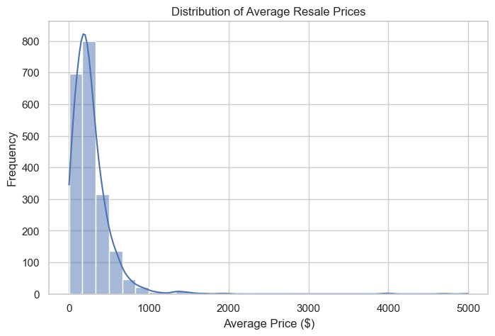

```python
plt.figure(figsize=(8,5))
sns.histplot(df_final3['Avg_Price'], bins=30, kde=True)
plt.title("Distribution of Average Resale Prices")
plt.xlabel("Average Price ($)")
plt.ylabel("Frequency")
plt.show()
```

- Insight:

Identifies underpriced & overpriced listings

Helps define fair market range

# Brand vs Average Price

## Which brands command higher resale prices?

```python
df_final3['Avg_Price'] = (
    df_final3['Min_Price ($)'] + df_final3['Max_Price ($)']
) / 2
```

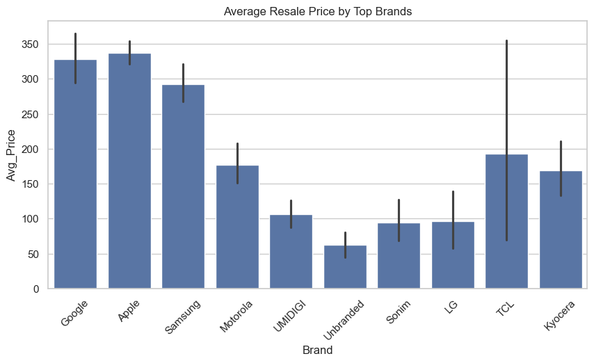

```python
top_brands = df_final3['Brand'].value_counts().head(10).index

plt.figure(figsize=(10,5))
sns.barplot(
    data=df_final3[df_final3['Brand'].isin(top_brands)],
    x='Brand',
    y='Avg_Price',
    estimator='mean'
)
plt.title("Average Resale Price by Top Brands")
plt.xticks(rotation=45)
plt.show()
```

- Insight:

Strong brand value impact

Sellers can price based on brand premium

# Brand vs Sales Volume

## Which brands sell the most?

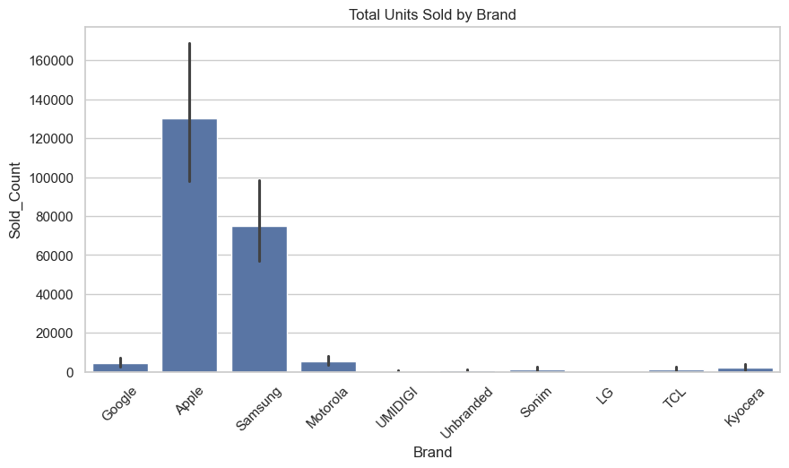

```python
plt.figure(figsize=(10,5))
sns.barplot(
    data=df_final3[df_final3['Brand'].isin(top_brands)],
    x='Brand',
    y='Sold_Count',
    estimator='sum'
)
plt.title("Total Units Sold by Brand")
plt.xticks(rotation=45)
plt.show()
```

- Insight:

Identifies high-demand brands

Helps sellers focus inventory

# Condition vs Price

## How much does condition affect pricing?

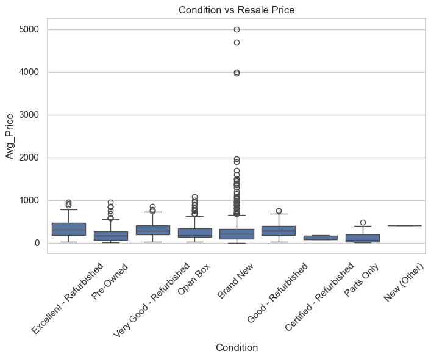

```python
plt.figure(figsize=(8,5))
sns.boxplot(data=df_final3, x='Condition', y='Avg_Price')
plt.title("Condition vs Resale Price")
plt.xticks(rotation=45)
plt.show()
```

- Insight:

Quantifies price depreciation

Helps buyers avoid overpaying

# Condition vs Sales

## Which condition sells the most?

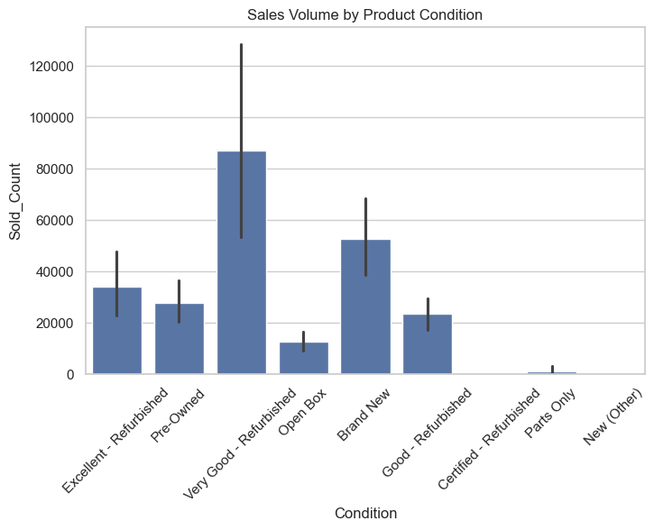

```python
plt.figure(figsize=(8,5))
sns.barplot(data=df_final3, x='Condition', y='Sold_Count', estimator='sum')
plt.title("Sales Volume by Product Condition")
plt.xticks(rotation=45)
plt.show()
```

- Insight:

Reveals buyer trust and preference

# ROM (Storage) vs Price

## Does higher storage increase resale price?

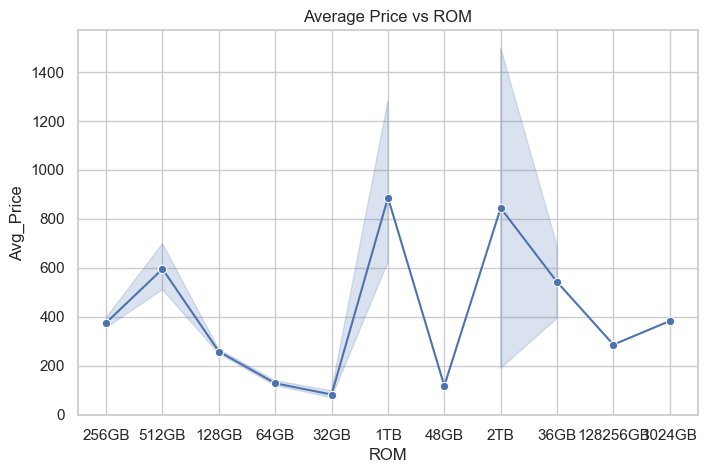

```python
plt.figure(figsize=(8,5))
sns.lineplot(data=df_final3, x='ROM', y='Avg_Price', estimator='mean', marker='o')
plt.title("Average Price vs ROM")
plt.show()
```

- Insight:

Storage has clear pricing tiers

Useful for bundle strategies

# ROM vs Sales Volume

## Which storage options are most popular?

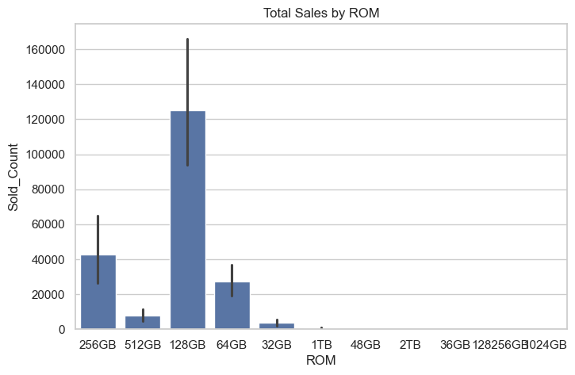

```python
plt.figure(figsize=(8,5))
sns.barplot(data=df_final3, x='ROM', y='Sold_Count', estimator='sum')
plt.title("Total Sales by ROM")
plt.show()
```

- Insight:

High sales not equall highest storage

Shows value-for-money sweet spot

# Shipping Cost vs Sales (Market Inefficiency)

## Do shipping costs affect sales?

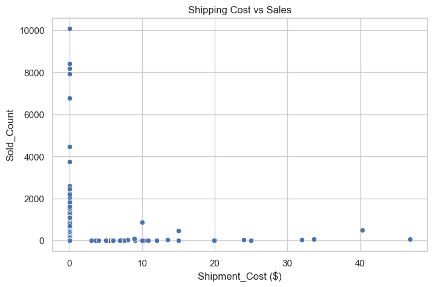

```python
plt.figure(figsize=(8,5))
sns.scatterplot(
    data=df_final3,
    x='Shipment_Cost ($)',
    y='Sold_Count'
)
plt.title("Shipping Cost vs Sales")
plt.show()
```

- Insight:

# Warranty Impact on Price

## Does warranty increase resale value?

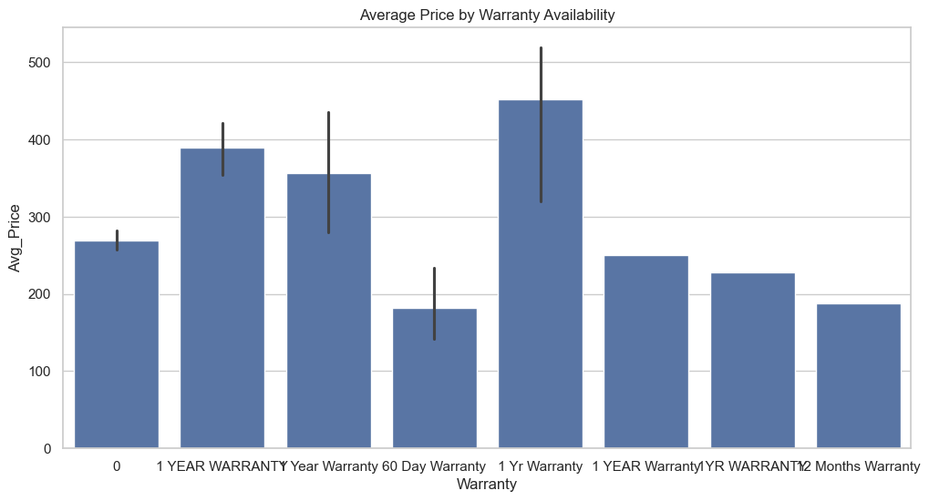

```python
plt.figure(figsize=(12,6))
sns.barplot(data=df_final3, x='Warranty', y='Avg_Price', estimator='mean')
plt.title("Average Price by Warranty Availability")
plt.show()
```

- Insight:

# Price vs Sales (Overpricing vs Underpricing)

## Is higher price always better?

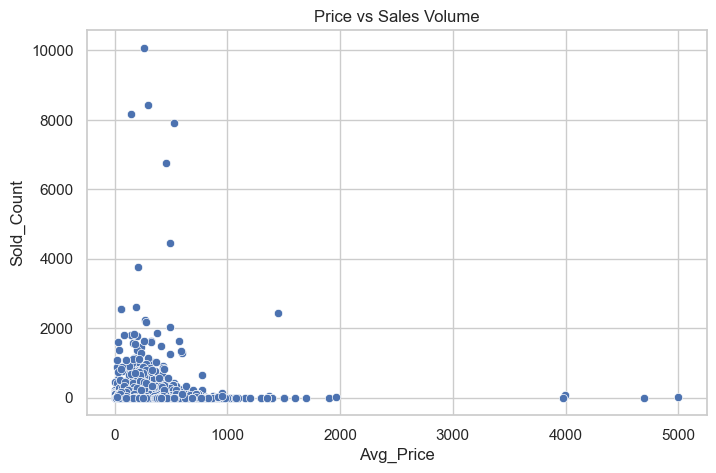

```python
plt.figure(figsize=(8,5))
sns.scatterplot(
    data=df_final3,
    x='Avg_Price',
    y='Sold_Count'
)
plt.title("Price vs Sales Volume")
plt.show()
```

- Insight:

Detects overpriced listings

Identifies sweet price zone

# Correlation Heatmap (Final Insight)

## What factors most influence resale price & sales?

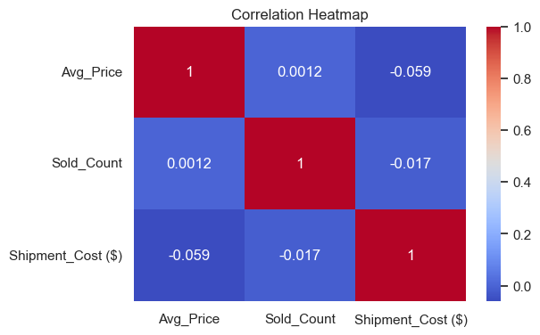

```python
plt.figure(figsize=(6,4))
sns.heatmap(
    df_final3[['Avg_Price', 'Sold_Count', 'Shipment_Cost ($)']].corr(),
    annot=True,
    cmap='coolwarm'
)
plt.title("Correlation Heatmap")
plt.show()
```

## Key Insights from Visualizations

- Sellers:

Brand & condition drive price premium

- Buyers:

Watch out for high price + low sales

Best deals often in mid-ROM tiers

- Market Inefficiency Solved:

`Data-driven pricing` `Transparent valuation` `Better buyer-seller trust`

# Hypothesis Testing & Visual Insights

## Exploratory Data Analysis of Factors Affecting Used Product Prices

```python
import pandas as pd
import numpy as np
import matplotlib.pyplot as plt
import seaborn as sns
from scipy.stats import ttest_ind, f_oneway, pearsonr

sns.set(style="whitegrid", palette="Set2")

# Ensure Avg_Price exists
df = df_final3.copy()
df['Avg_Price'] = (df['Min_Price ($)'] + df['Max_Price ($)']) / 2
```

## Condition affects resale price

- Hypotheses

H₀ (Null): Product condition has no effect on resale price

H₁ (Alternative): Product condition significantly affects resale price

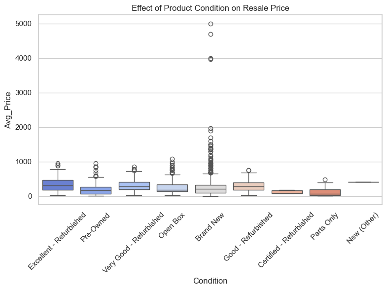

```python
plt.figure(figsize=(9,5))
sns.boxplot(
    data=df,
    x='Condition',
    y='Avg_Price',
    palette='coolwarm'
)
plt.title("Effect of Product Condition on Resale Price")
plt.xticks(rotation=45)
plt.show()
```

## Statistical Test (ANOVA)

```python
groups = [group['Avg_Price'].values for name, group in df.groupby('Condition')]
f_stat, p_value = f_oneway(*groups)

print("F-statistic:", f_stat)
print("P-value:", p_value)
```

```
F-statistic: 9.160275743085446
P-value: 1.8769230336932754e-12
```

- Insight p < 0.05 Reject H₀

Product condition significantly influences resale price

Implication: Sellers should price aggressively based on condition.

## Brand impacts resale price

- Hypotheses

H₀: Brand has no impact on resale price

H₁: Brand significantly impacts resale price

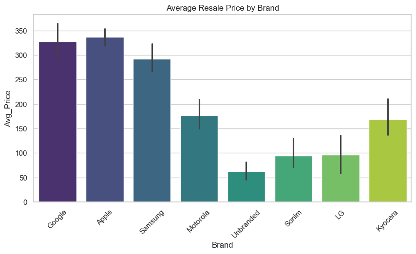

```python
top_brands = df['Brand'].value_counts().head(8).index

plt.figure(figsize=(10,5))
sns.barplot(
    data=df[df['Brand'].isin(top_brands)],
    x='Brand',
    y='Avg_Price',
    estimator='mean',
    palette='viridis'
)
plt.title("Average Resale Price by Brand")
plt.xticks(rotation=45)
plt.show()
```

## Statistical Test (ANOVA)

```python
brand_groups = [
    group['Avg_Price'].values
    for name, group in df[df['Brand'].isin(top_brands)].groupby('Brand')
]

f_stat, p_value = f_oneway(*brand_groups)
print("P-value:", p_value)
```

```
P-value: 5.352982138733484e-20
```

- Insight

Brand premium exists

Certain brands command significantly higher resale value